# R Markdown

BTM, 20th October 2016

## What is R Markdown

- Framework for creating dynamic documents, reports and presentations
- A tool for integration of R-code execution results into your document

. . .

## Why do we need it?

- To ensure reproducibility of the results
- To convert the .Rmd file into different formats
  - HTML
  - PDF
  - MS Word (ODT, RTF)
  - Markdown
  - Presentations: ioslides, reveal.js, Slidy, Beamer
  - Website templates
- Easy to write and format your documents
- To share open code, ideas, algotirhms and research results

## Reproducible research and collaboration

- [Paper in "Nature"](http://www.nature.com/news/1-500-scientists-lift-the-lid-on-reproducibility-1.19970): more than 70% of respondents can not reproduce their colleagues' results
- And it gets worse:
  - More data
  - Complex data analysis schemes
  - Models and algorithms need a lot of fine tuning
  - Traditional journal paper format is not enough anymore
- [Ropensci reproducibility guide](http://ropensci.github.io/reproducibility-guide/)

## An introduction to Rmarkdown: Inline code

- Simplest stuff: insert the result as text inside a string
- Syntaxis: backtick ("`") - "r" - space - R-code - backtick
- Example: "The theorem is proven under the assumption pi equals `` `r ceiling(pi)` ``."
- Result: "The theorem is proven under the assumption pi equals 4."

## An introduction to Rmarkdown: Code chunks

- The basic way to insert code
- Every chunk can be tuned separately using options
- Chunk may print something out, draw a plot or have no output

## An introduction to Rmarkdown: Chunk syntaxis

````
```{r}
head(iris)
```
````

. . .

```r
head(iris)
```

```
##   Sepal.Length Sepal.Width Petal.Length Petal.Width Species
## 1          5.1         3.5          1.4         0.2  setosa
## 2          4.9         3.0          1.4         0.2  setosa
## 3          4.7         3.2          1.3         0.2  setosa
## 4          4.6         3.1          1.5         0.2  setosa
## 5          5.0         3.6          1.4         0.2  setosa
## 6          5.4         3.9          1.7         0.4  setosa
```

## An introduction to Rmarkdown: Option echo=FALSE

- You can put *options* for a chunk in figure brackets
- By default both code and results are shown
- Option `echo=FALSE` supresses printing the code:

. . .

````
```{r, echo=FALSE}
(1:10)^3
```
````

. . .

```
##  [1]    1    8   27   64  125  216  343  512  729 1000
```

## An introduction to Rmarkdown: Layout

- `**Bold** __font__` –> **Bold** **font**
- `*Italic* _font_` –> *Italic* *font*
- Monospeced text `` `sum(x)` `` –> `sum(x)`
- Upper and lower indices `A^2^~i~` –> A<sup>2</sup><sub>i</sub>
- `~~Strikeout~~ text` –> Strikeout text
- Symbols escape: `\* \_ \\ \$` –> * _ \ $
- Autocorrection of dash and long dash: `-- ---` –> – —

## Main elements of Markdown

- Headers: `# Header 1` – `###### Header 6`
- Hyperlink: `<https://www.github.com/nvolkova>` –> https://www.github.com/nvolkova
- Hyperlink in text: `[My github](https://www.github.com/nvolkova)` –> [My github](https://www.github.com/nvolkova)
- http://www.rstudio.com/wp-content/uploads/2016/03/rmarkdown-cheatsheet-2.0.pdf

## Latex support

- To build a pdf you need to install \(\TeX\) (MiKTeX, TeX Live)
- `$\hat{\beta} = (X^T X)^{-1} X^T y$` –> \(\hat{\beta} = (X^T X)^{-1} X^T y\)
- `$$i \hbar \frac{\partial}{\partial t} ... $$` –> \[i \hbar \frac{\partial}{\partial t}\Psi(\mathbf{r},t) = \hat H \Psi(\mathbf{r},t)\]
- It has all the functions available in \(\TeX\) (settings, packages, macros etc.)
- Formulas are shown correctly in HTML thanks to MathJax

## knitr

- Tha package `knitr` processes Rmarkdown code
- Can also be used independently from R Markdown
- Initial focus of `knitr` – pdf (LaTeX + R)

## Global options

- Usually given in the beginning of a document
- `knitr::opts_chunk$set(echo=FALSE, fig.width=5, fig.height=5)`
- It's convenient to put it in a separate chunk with an option `include=FALSE`

## Chunk options

- There are several global `knitr` settings
- Every chunk can have its own local settings that overwrite global
- Local settings should be separated by comma
- The list of settings can be foound on http://yihui.name/knitr/options/

## Main options

- `echo` (default: `TRUE`) – showing the sourcecode
- `eval` (default: `TRUE`) – executing the chunk
- `include` (default: `TRUE`) – showing the execution result
- `error` (default: `FALSE`) – showing error text
- `message` (default: `TRUE`) – showing message text
- `warning` (default: `TRUE`) – showing warning text

## Main options

- `comment` (default: `'##'`) – prefix to be set before every output string
- `results` (default: `'markup'`) – output layout
- `highlight` (default: `TRUE`) – highlighting code syntaxis
- `tidy` (default: `FALSE`) – formatting (spaces and indents)

## Chunk labels

- You can put a label in the curved brackets between "r" and chunk options
- Chunks can call each other by labels

. . .

````
```{r chunk1, echo=TRUE, results='hide'}
cos(2*pi)
```
````

````
```{r chunk2, echo=FALSE, ref.label='chunk1'}
```
````

. . .

```r
cos(2*pi)
```

```
## [1] 1
```

## Graphics

- `fig.height`, `fig.width` – image size (in inches)
- `fig.align` (default: `'center'`) – image position on the page
- `fig.cap` (default: `NULL`) – string with image subtitle

. . .

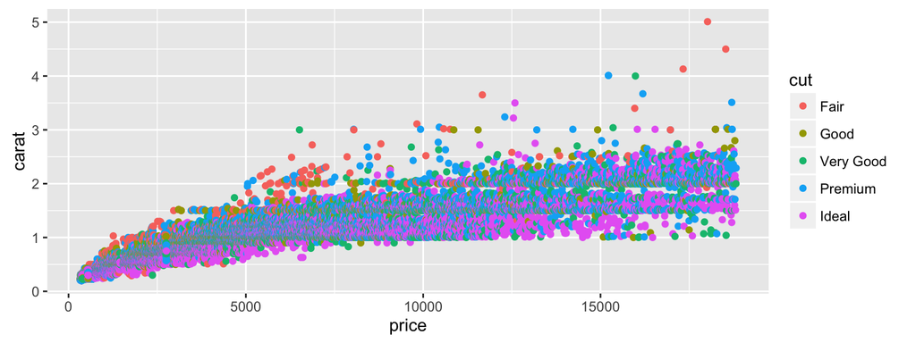

## Caching

- Some chunks may contain lots of calculations
- For those you'd like to put `cache=TRUE`
- Cache only works when nothing inside a chunk has changed
- NB: if your chunks are tied, remember about the cache!
- In such cases you could use the function `dependson`
- NB: some algorithms may use random number generators!

## Getting started

- Make sure you have installed the following if you haven’t already done so
  - R (https://cran.rstudio.com/)
  - Rstudio (https://www.rstudio.com/products/rstudio/download/)
- Get into pairs

[figure not shown]

## Getting started

[figure not shown]

- Create a new Rmarkdown (Rmd) document
- File → Newfile → R markdown…
- Follow the prompt to install knitr (if it appears)
- Set a title for your document
- Enter your name in the author field and hit “OK”

## Hands-on tutorial

- Exercise 1: Simple syntax and code chunks (15 mins)
- Aims:
  - Familiarise yourself with basic markdown syntax
  - Get comfortable with generating reports, and running code chunks
  - Use them to print statements and tables
  - Play with the code chunks options

## Hands-on tutorial

- Play around with basic rmarkdown
- Download exercise 1 HTML: https://github.com/nvolkova/btm-2016/
- Try to generate a similar report
- There is also a cheat sheet there to help you
- You can play around with Rmarkdown demo http://dillinger.io/ for further help too

## Hands-on tutorial

- Exercise 2: Plotting, caching and formatting (15 mins)
- Aims:
  - Learning more advanced chunk options for plotting
  - Learn how to cache chunks

## Bonus exercise: generating slides

- You can even generate nifty html slides with Rmarkdown
- Just add “output: ioslides_presentation” to the header

. . .

```
---
title: "My awesome Rmarkdown presentation"
author: "EMBL predocs"
date: October 20, 2016
output: ioslides_presentation
---
```

## The end!

Thank you for being here!

Nadia and Nacho.